# Лабораторная работа №2

Управление пользователями и группами

Тукаев Тимур

Российский университет дружбы народов, Москва, Россия

9 декабря 2025

# Цель работы

## Основная цель

Получить представление о работе с учётными записями пользователей и группами пользователей в ОС типа Linux и закрепить практические навыки их администрирования.

# Ход выполнения работы

## Переключение учётных записей

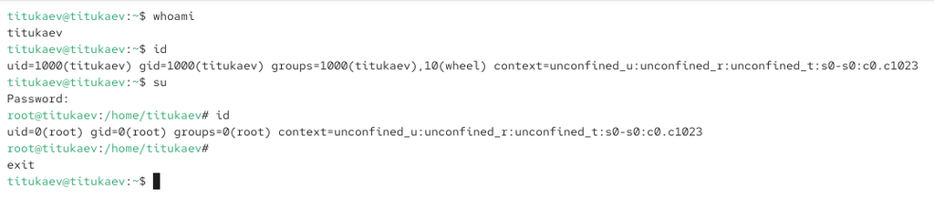

Определение пользователя и его групп

Определение активного пользователя и его групп (`whoami`, `id`).  
Переход в режим суперпользователя `root` и возврат к обычному пользователю.

## Просмотр и настройка sudoers

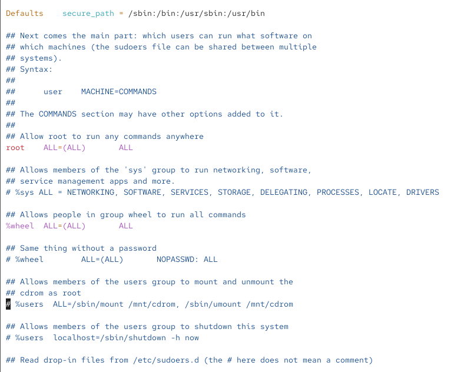

Файл sudoers, открытый через visudo

Безопасное редактирование `/etc/sudoers` через `visudo`.  
Анализ записи `%wheel ALL=(ALL) ALL` и роли группы `wheel` для выдачи прав через `sudo`.

## Создание пользователей alice и bob

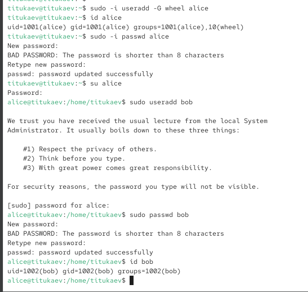

Создание пользователей alice и bob

Создание пользователя `alice`, включение его в группу `wheel`.  
Создание пользователя `bob`, назначение паролей и проверка параметров учётных записей.

## Настройка параметров создания пользователей

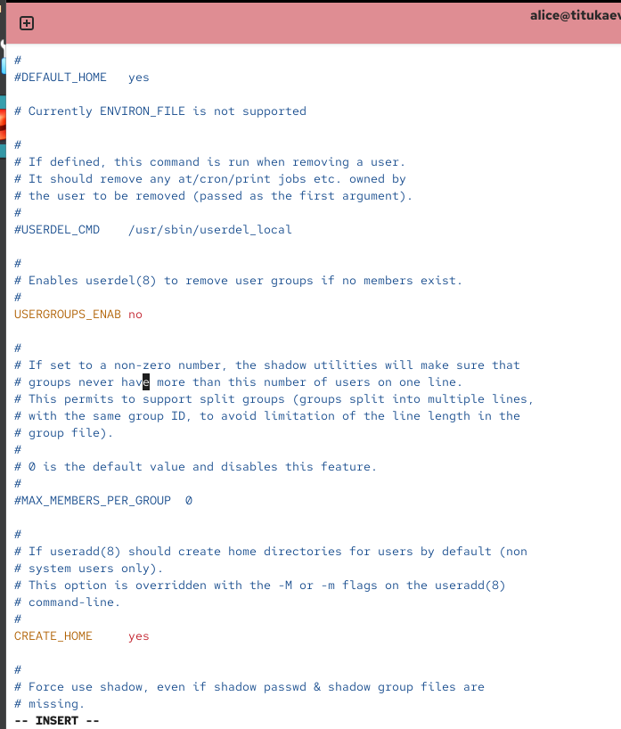

Редактирование файла /etc/login.defs

Изменение общесистемных настроек в `/etc/login.defs`:  
включение `CREATE_HOME` и установка `USERGROUPS_ENAB no`.

Настройка шаблонов в `/etc/skel` (каталоги `Documents`, `Pictures`, файлы и переменная `EDITOR`).

## Шаблоны окружения в /etc/skel

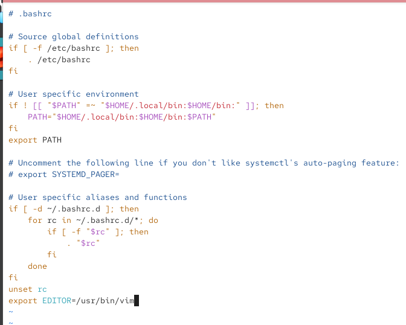

Настройка EDITOR и .bashrc

Добавление `export EDITOR=/usr/bin/vim` в `.bashrc` из `/etc/skel`.  
Формирование единых настроек окружения для всех новых пользователей.

## Создание учётной записи carol

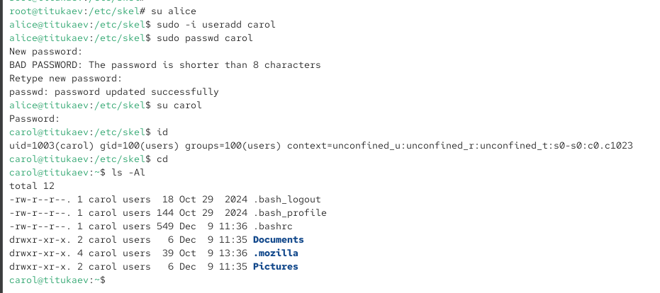

Домашний каталог и информация о carol

Создание пользователя `carol` с использованием новых настроек.  
Проверка основной группы `users` и наличия каталогов `Documents` и `Pictures` в домашнем каталоге.

## Работа с /etc/shadow и параметрами пароля

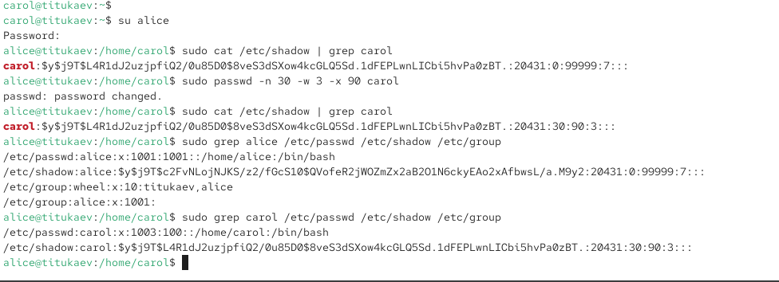

Просмотр и изменение записи carol в /etc/shadow

Анализ записи пользователя `carol` в `/etc/shadow`.  
Настройка сроков действия пароля (`-n 30`, `-w 3`, `-x 90`) и повторная проверка записи.

## Управление группами пользователей

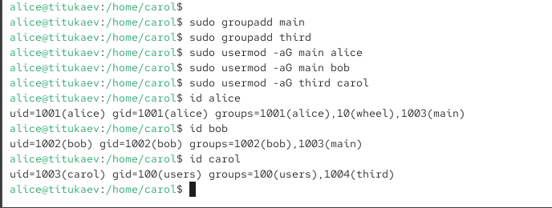

Создание групп и проверка их состава

Создание групп `main` и `third`.  
Добавление пользователей `alice`, `bob`, `carol` в соответствующие группы и анализ их членства (`id`).

# Итоги работы

## Вывод

В ходе лабораторной работы освоены приёмы администрирования пользователей и групп в Linux.  
Рассмотрены механизмы выдачи привилегий через `sudo`, создание и настройка учётных записей, управление паролями и групповой принадлежностью.  
Полученные навыки являются базовыми для дальнейшего изучения системного администрирования в Unix-подобных системах.